**Regression**

Table of Contents

# 1. Linear Regression

Regression is a fundamental concept in machine learning, playing a crucial role in understanding and predicting continuous outcomes based on input features. Unlike classification, which assigns data points to discrete categories, regression models aim to establish a relationship between independent variables (features) and a continuous dependent variable (target).

At its core, regression seeks to capture patterns in data and predict numerical values by minimizing the error between the predicted values and the actual values. This makes regression indispensable for a wide range of applications.

```python
from IPython.display import YouTubeVideo
YouTubeVideo('IRrGVQV8vZ8', width = "560", height = "315")
```

[video not shown]

## 1.1. Linear Regression: Problem Setup

Let's begin by considering a simple linear regression problem, where the goal is to predict a continuous output based on a single input feature.

Given a dataset of input-output pairs:

$$\; \begin{cases}x_{i} \; \text{: inputs} \\y_{i} \; \text{: outputs}\end{cases} \qquad \text{for} \;i = 1, 2, \cdots, m$$

We can organize the inputs and outputs as column vectors:

$$x= \begin{bmatrix} x_{1} \\ x_{2} \\ \vdots \\ x_{m} \end{bmatrix}, \qquad y= \begin{bmatrix} y_{1} \\ y_{2} \\ \vdots \\ y_{m} \end{bmatrix}$$

**Prediction Model**

Let $\hat{y}_i$ be the predicted output for input $x_i$. In general, we assume there's a function $f(x_i; \theta)$ that maps the input to the predicted output, parameterized by $\theta$:

$$ \hat{y}_{i} = f(x_{i}\,; \theta) $$

For linear regression, we use a linear model to approximate the relationship between $x_i$ and $y_i$:

$$y_i \approx \hat{y}_{i} = \theta_{0} + \theta_{1}x_{i}$$

Here,

- $\theta_0$ is the intercept (bias term),
- $\theta_1$ is the slope (weight) of the input, and
- $\theta = \begin{bmatrix} \theta_0 \\ \theta_1 \end{bmatrix}$ are the model parameters we want to learn.

**Objective: Minimizing Prediction Error**

To find the best values of $\theta_0$ and $\theta_1$, we minimize the sum of squared errors between the predicted values $\hat{y}_i$ and the actual values $y_i$:

$$ \min\limits_{\theta_{0}, \theta_{1}}\sum\limits_{i = 1}^{m} \left(\hat{y}_{i} - y_{i} \right)^2$$

This is known as the least squares criterion and is a standard method for fitting linear models.

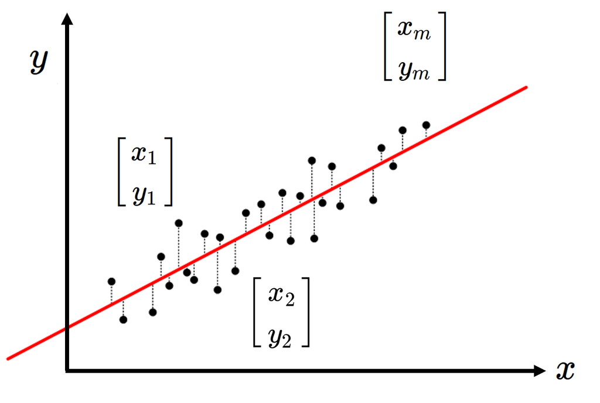

**Vector Form of the Model**

We can express the model for all data points at once using vectors and matrix operations:

$$ y= \begin{bmatrix} y_{1} \\ y_{2} \\ \vdots \\ y_{m} \end{bmatrix} \approx \begin{bmatrix} \hat y_{1} \\ \hat y_{2} \\ \vdots \\ \hat y_{m} \end{bmatrix} = \theta_{0} \begin{bmatrix} 1 \\ 1 \\ \vdots \\ 1 \end{bmatrix} + \theta_{1} \begin{bmatrix} x_{1} \\ x_{2} \\ \vdots \\ x_{m} \end{bmatrix}$$

## 1.2. Re-cast Problem as a Least Squares

For convenience, we define a function that maps inputs to feature vectors, denoted as $\phi$

$$\begin{array}{Icr}\begin{align*} \hat{y}_{i} & = \theta_0 + x_i \theta_1 = 1 \cdot \theta_0 + x_i \theta_1 \\ \\ & = \begin{bmatrix}1 & x_{i}\end{bmatrix}\begin{bmatrix}\theta_{0} \\ \theta_{1}\end{bmatrix} \\\\ & =\begin{bmatrix}1 \\ x_{i} \end{bmatrix}^{T}\begin{bmatrix}\theta_{0} \\ \theta_{1}\end{bmatrix} \\\\ & =\phi^{T}(x_{i})\theta \end{align*}\end{array} \begin{array}{Icr} \quad \quad \text{feature vector} \; \phi(x_{i}) = \begin{bmatrix}1 \\ x_{i}\end{bmatrix} \end{array}$$

We can then construct the matrix $\Phi$ by stacking the transposed feature vectors for all $m$ data points:

$$\Phi = \begin{bmatrix}1 & x_{1} \\ 1 & x_{2} \\ \vdots \\1 & x_{m} \end{bmatrix}=\begin{bmatrix}\phi^T(x_{1}) \\\phi^T(x_{2}) \\\vdots \\\phi^T(x_{m}) \end{bmatrix} \quad \implies \quad \hat{y} = \begin{bmatrix}\hat{y}_{1} \\\hat{y}_{2} \\\vdots \\\hat{y}_{m}\end{bmatrix}=\Phi\theta$$

**Optimization Problem (or Least Squares)**

We aim to minimize the total squared error:

$$\min\limits_{\theta_{0}, \theta_{1}}\sum\limits_{i = 1}^{m} (\hat{y}_{i} - y_{i})^2 =\color{red}{\min\limits_{\theta}\lVert\Phi\theta-y\rVert^2_2} \qquad \qquad \left(\text{same as} \; \min_{x} \lVert Ax-b \rVert_2^2 \right)$$

The solution to this least squares problem is:

$$ \theta^* = (A^TA)^{-1}A^T b $$

**Why?** (here, $A_i$ means the $i$th row of matrix $A$)

$$\sum_{i=1}^{m} \lvert \underbrace{ A_i x - b_i}_{\text{scalar}} \rvert^2 = \left\| \begin{bmatrix} A_1 x - b_1 \\ \vdots \\ A_m x - b_m \end{bmatrix} \right\|^2 = \left\| \begin{bmatrix} A_1 \\ \vdots \\ A_m \end{bmatrix} x - \begin{bmatrix} b_1 \\ \vdots \\ b_m \end{bmatrix} \right\|^2 = \lVert \underbrace{Ax-b}_{\text{vector}} \rVert_2^2$$

Note

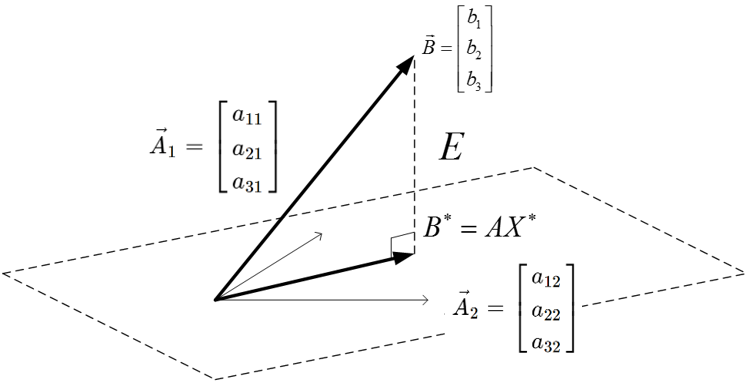

From Input to Prediction (Feature Mapping + Linear Model)

$$\begin{array}{Icr} \text{input} \\ x_{i} \end{array} \quad \rightarrow \quad \begin{array}{Icr} \text{feature vector} \\ \begin{bmatrix} 1 \\ x_{i} \end{bmatrix} \end{array} \quad \rightarrow \quad \begin{array}{Icr} \text{predicted output} \\ \hat{y}_{i} \end{array}$$

**Matrix Form of the Linear System**

We collect all feature vectors into a design matrix and model the predictions as:

$$ \underbrace{ \begin{bmatrix} 1 & x_1 \\ 1 & x_2 \\ \vdots & \vdots \\ 1 & x_m \end{bmatrix} }_{A = \Phi} \underbrace{ \begin{bmatrix} \theta_0 \\ \theta_1 \end{bmatrix} }_{\theta} = \underbrace{ \begin{bmatrix} y_1 \\ y_2 \\ \vdots \\ y_m \end{bmatrix} }_{y} $$

Below each column of $A$, we can identify the column vectors (features):

$$ \begin{array}{cccccc} \vec{A}_1 = \begin{bmatrix}1 \\ 1 \\ \vdots \\ 1\end{bmatrix}, & \quad \vec{A}_2 = \begin{bmatrix}x_1 \\ x_2 \\ \vdots \\ x_m\end{bmatrix} , &\quad \quad \theta = \begin{bmatrix} \theta_0 \\ \theta_1 \end{bmatrix}, & \quad \quad y = \begin{bmatrix} y_1 \\ y_2 \\ \vdots \\ y_m \end{bmatrix} \end{array} $$

This system is typically over-determined (more equations than unknowns), so we seek the best approximate solution via least squares projection.

$$A(= \Phi) = \begin{bmatrix} \vec{A}_1 & \vec{A}_2 \end{bmatrix}$$

## 1.3. Solve Optimizaton in Linear Regression

### 1.3.1. Solution via Linear Algebra

The linear regression problem can be solved analytically using linear algebra, in what is known as the least squares solution. The optimal solution is given by the normal equation:

$$ \theta = (A^TA)^{-1}A^T y $$

```python
import numpy as np
import matplotlib.pyplot as plt
%matplotlib inline
```

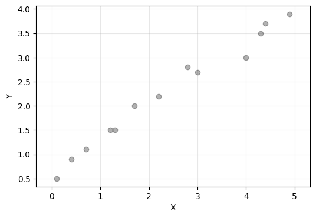

```python
# data points in column vector [input, output]
x = np.array([0.1, 0.4, 0.7, 1.2, 1.3, 1.7, 2.2, 2.8, 3.0, 4.0, 4.3, 4.4, 4.9]).reshape(-1, 1)
y = np.array([0.5, 0.9, 1.1, 1.5, 1.5, 2.0, 2.2, 2.8, 2.7, 3.0, 3.5, 3.7, 3.9]).reshape(-1, 1)

plt.figure(figsize = (6, 4))
plt.plot(x, y, 'ko', alpha = 0.3)
plt.xlabel('X')
plt.ylabel('Y')
plt.axis('equal')
plt.grid(alpha = 0.3)
plt.show()
```

```python
m = y.shape[0]
#A = np.hstack([np.ones([m, 1]), x])
A = np.hstack([x**0, x])
A = np.asmatrix(A)

theta = (A.T*A).I*A.T*y

print('theta:\n', theta)
```

```
theta:
 [[0.65306531]
 [0.67129519]]
```

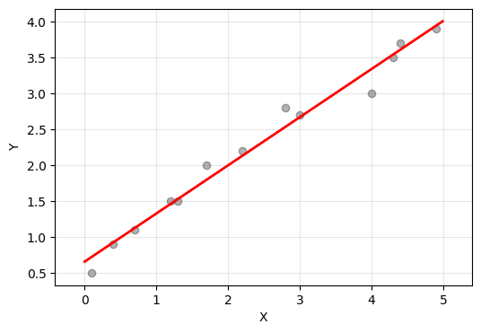

```python
# to plot
plt.figure(figsize = (6, 4))
plt.xlabel('X')
plt.ylabel('Y')
plt.plot(x, y, 'ko', label = "data", alpha = 0.3)

# to plot a straight line (fitted line)
xp = np.arange(0, 5, 0.01).reshape(-1, 1)
yp = theta[0,0] + theta[1,0]*xp

plt.plot(xp, yp, 'r', linewidth = 2, label = "regression")
# plt.legend()
plt.axis('equal')
plt.grid(alpha = 0.3)
plt.show()
```

### 1.3.2. Solving with Gradient Descent

Instead of solving the normal equation analytically, we can also minimize the loss function using gradient descent, an iterative optimization method.

We aim to solve:

$$\min_{\theta} ~ \lVert \hat y - y \rVert_2^2 = \min_{\theta} ~ \lVert A\theta - y \rVert_2^2$$

Let the objective function be:

$$f(\theta) = \lVert A\theta - y \rVert_2^2 = (A\theta - y)^T (A\theta - y)$$

Expand the objective function:

$$ \begin{align*} f(\theta) &= (A\theta-y)^T(A\theta-y) \\ &= (\theta^TA^T-y^T)(A\theta-y) \\ &= \theta^TA^TA\theta - \theta^TA^Ty - y^TA\theta + y^Ty \\\\ \nabla_{\theta} f &= A^TA\theta + A^TA\theta - A^Ty - A^Ty = 2(A^TA\theta - A^Ty) \end{align*} $$

Gradient descent update rule:

$$ \theta \leftarrow \theta - \alpha \nabla_{\theta} f = \theta - 2 \alpha (A^TA\theta - A^Ty) $$

```python
theta = np.random.randn(2,1)
theta = np.asmatrix(theta)

alpha = 0.001

for _ in range(1000):
    df = 2*(A.T*A*theta - A.T*y)
    theta = theta - alpha*df

print(theta)
```

```
[[0.65261835]
 [0.67143025]]
```

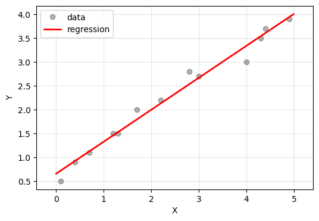

```python
# to plot
plt.figure(figsize = (6, 4))
plt.xlabel('X')
plt.ylabel('Y')
plt.plot(x, y, 'ko', label = "data", alpha = 0.3)

# to plot a straight line (fitted line)
xp = np.arange(0, 5, 0.01).reshape(-1, 1)
yp = theta[0,0] + theta[1,0]*xp

plt.plot(xp, yp, 'r', linewidth = 2, label = "regression")
plt.legend()
plt.axis('equal')
plt.grid(alpha = 0.3)
plt.show()
```

### 1.3.3. Solving with CVXPY (Convex Optimization)

Another way to solve the linear regression problem is by using CVXPY, a Python library for convex optimization.

$$\min_{\theta} ~ \lVert \hat y - y \rVert_2 = \min_{\theta} ~ \lVert A\theta - y \rVert_2$$

```python
import cvxpy as cvx

theta2 = cvx.Variable([2, 1])
obj = cvx.Minimize(cvx.norm(A@theta2 - y, 2))
cvx.Problem(obj,[]).solve()

print('theta:\n', theta2.value)
```

```
theta:
 [[0.65306531]
 [0.67129519]]
```

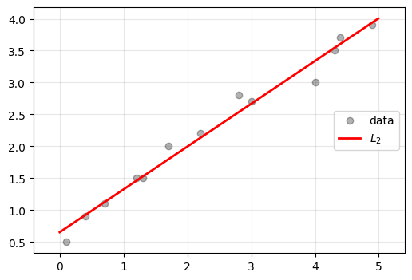

```python
# to plot straight lines (fitted lines)
plt.figure(figsize = (6, 4))
plt.plot(x, y, 'ko', label = 'data', alpha = 0.3)
xp = np.arange(0, 5, 0.01).reshape(-1,1)
yp2 = theta2.value[0,0] + theta2.value[1,0]*xp

plt.plot(xp, yp2, 'r', linewidth = 2, label = '$L_2$')
plt.axis('equal')
plt.legend(loc = 5)
plt.grid(alpha = 0.3)
plt.show()
```

### 1.3.4. Scikit-Learn

Scikit-Learn is a powerful and user-friendly machine learning library in Python. It provides efficient implementations of many standard algorithms, including linear regression.

- Simple and efficient tools for data mining and data analysis
- Accessible to everybody, and reusable in various contexts
- Built on NumPy, SciPy, and Matplotlib
- Open source
- https://scikit-learn.org/stable/index.html#

```python
from sklearn import linear_model
```

```python
reg = linear_model.LinearRegression()
reg.fit(x, y)
```

```
LinearRegression()
```

```python
reg.coef_
```

```
array([[0.67129519]])
```

```python
reg.intercept_
```

```
array([0.65306531])
```

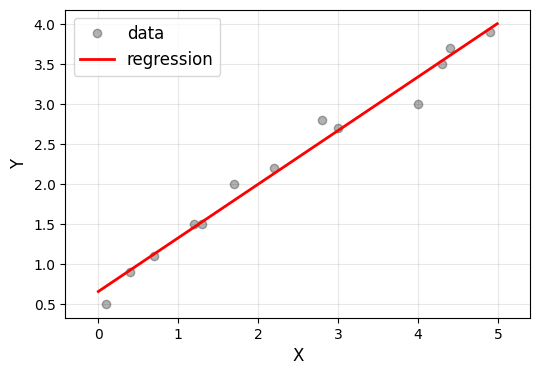

```python
# to plot
plt.figure(figsize = (6, 4))
plt.xlabel('X', fontsize = 12)
plt.ylabel('Y', fontsize = 12)
plt.plot(x, y, 'ko', label = "data", alpha = 0.3)

# to plot a straight line (fitted line)
plt.plot(xp, reg.predict(xp), 'r', linewidth = 2, label = "regression")
plt.legend(fontsize = 12)
plt.axis('equal')
plt.grid(alpha = 0.3)
plt.show()
```

We have demonstrated four different implementations of linear regression: least squares, gradient descent, CVXPY, and Scikit-Learn.

### 1.3.5. L1 Norm

In the objective function, the error is defined as the difference between the predicted value and the ground truth. To measure the magnitude or strength of this error, the L2 norm is typically used, as it provides a smooth and differentiable measure of error, making it convenient for optimization.

However, as we have learned, there are many different norms available. It is often interesting to explore what happens when a different norm, such as the L1 norm, is used instead. The choice of norm can significantly impact the behavior and properties of the optimization process, affecting factors such as robustness, sparsity, and computational efficiency.

Let's use $L_1$ norm

$$ \min_{\theta} ~ \lVert \hat y - y \rVert_1 = \min_{\theta} ~ \lVert A\theta - y \rVert_1 $$

You might wonder how to solve this optimization problem since the L1 norm is used in the objective function. However, we will use CVXPY to find the optimal solution. You do not need to worry too much about the algorithm running beneath CVXPY.

```python
theta1 = cvx.Variable([2, 1])
obj = cvx.Minimize(cvx.norm(A@theta1 - y, 1))
cvx.Problem(obj).solve()

print('theta:\n', theta1.value)
```

```
theta:
 [[0.6258208]
 [0.685448 ]]
```

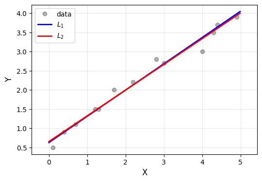

```python
# to plot data
plt.figure(figsize = (6, 4))
plt.xlabel('X', fontsize = 12)
plt.ylabel('Y', fontsize = 12)
plt.plot(x, y, 'ko', label = 'data', alpha = 0.3)

# to plot straight lines (fitted lines)
xp = np.arange(0, 5, 0.01).reshape(-1, 1)
yp1 = theta1.value[0,0] + theta1.value[1,0]*xp
yp2 = theta2.value[0,0] + theta2.value[1,0]*xp

plt.plot(xp, yp1, 'b', linewidth = 2, label = '$L_1$')
plt.plot(xp, yp2, 'r', linewidth = 2, label = '$L_2$')
plt.legend()
plt.axis('equal')
plt.grid(alpha = 0.3)
plt.show()
```

Interestingly, the $L_1$ norm also provides a reasonable linear approximation. Therefore, at this point, you might conclude that the choice of distance definition does not significantly impact the results.

However, to truly understand their differences, let's consider a scenario where outliers are present in the dataset.

What Happens When Outliers Exist?

- We'll fit the data using both the L1 and L2 norms.
- Then, we'll compare the resulting models and discuss the differences.
- This will help highlight the sensitivity of each norm to outliers and clarify why the choice of distance metric matters.

```python
# add outliers
x = np.vstack([x, np.array([0.5, 3.8]).reshape(-1, 1)])
y = np.vstack([y, np.array([3.0, 1.0]).reshape(-1, 1)])

A = np.hstack([x**0, x])
A = np.asmatrix(A)
```

```python
A.shape
```

```
(15, 2)
```

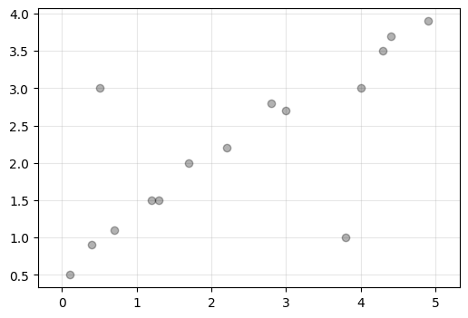

```python
plt.figure(figsize = (6, 4))
plt.plot(x, y, 'ko', label = 'data', alpha = 0.3)
plt.axis('equal')
plt.grid(alpha = 0.3)
plt.show()
```

L2 norm

```python
theta2 = cvx.Variable([2, 1])
obj2 = cvx.Minimize(cvx.norm(A@theta2 - y, 2))
prob2 = cvx.Problem(obj2).solve()
```

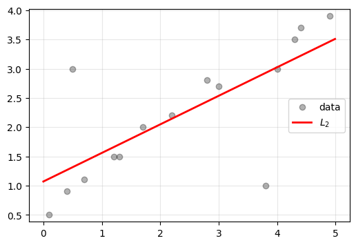

```python
# to plot straight lines (fitted lines)
plt.figure(figsize = (6, 4))
plt.plot(x, y, 'ko', label = 'data', alpha = 0.3)
xp = np.arange(0, 5, 0.01).reshape(-1,1)
yp2 = theta2.value[0,0] + theta2.value[1,0]*xp

plt.plot(xp, yp2, 'r', linewidth = 2, label = '$L_2$')
plt.axis('equal')
plt.legend(loc = 5)
plt.grid(alpha = 0.3)
plt.show()
```

L1 norm

```python
theta1 = cvx.Variable([2, 1])
obj1 = cvx.Minimize(cvx.norm(A@theta1 - y, 1))
prob1 = cvx.Problem(obj1).solve()
```

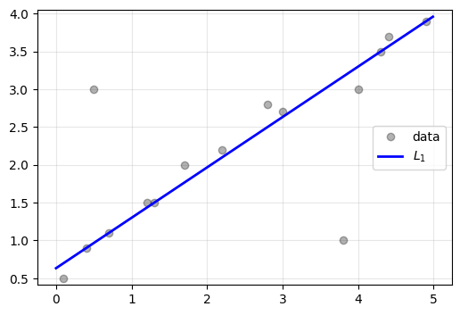

```python
# to plot straight lines (fitted lines)
plt.figure(figsize = (6, 4))
plt.plot(x, y, 'ko', label = 'data', alpha = 0.3)
xp = np.arange(0, 5, 0.01).reshape(-1,1)
yp1 = theta1.value[0,0] + theta1.value[1,0]*xp

plt.plot(xp, yp1, 'b', linewidth = 2, label = '$L_1$')
plt.axis('equal')
plt.legend(loc = 5)
plt.grid(alpha = 0.3)
plt.show()
```

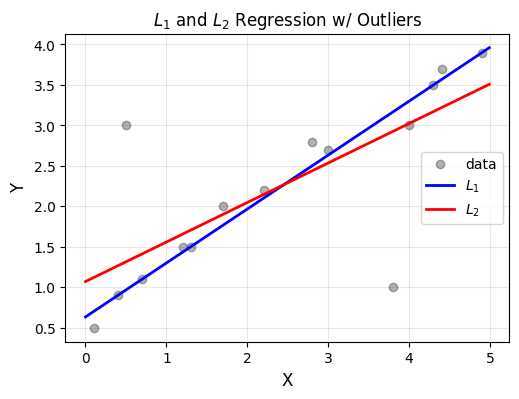

```python
# to plot data
plt.figure(figsize = (6, 4))
plt.plot(x, y, 'ko', label = 'data', alpha = 0.3)
plt.title('$L_1$ and $L_2$ Regression w/ Outliers', fontsize = 12)
plt.xlabel('X', fontsize = 12)
plt.ylabel('Y', fontsize = 12)

# to plot straight lines (fitted lines)
xp = np.arange(0, 5, 0.01).reshape(-1,1)
yp1 = theta1.value[0,0] + theta1.value[1,0]*xp
yp2 = theta2.value[0,0] + theta2.value[1,0]*xp

plt.plot(xp, yp1, 'b', linewidth = 2, label = '$L_1$')
plt.plot(xp, yp2, 'r', linewidth = 2, label = '$L_2$')
plt.axis('scaled')
plt.legend(loc = 5)
plt.grid(alpha = 0.3)
plt.show()
```

The key differences between these two regression approaches arise from how they handle outliers in the data.

(1) Sensitivity to Outliers in L2-Norm Regression

- The L2 norm minimizes the sum of squared errors:

  $$\min ~ \sum \left( \hat y - y \right)^2 $$
- Squaring the residuals magnifies the effect of large errors, meaning that outliers have a significant influence on the final regression line.
- As a result, the L2 regression line (red) is pulled towards the outliers, making it less robust.

(2) Robustness of L1-Norm Regression

- The L1 norm minimizes the sum of absolute errors:

  $$\min ~ \sum \lvert \hat y - y \rvert $$
- Since absolute differences are not squared, large errors (outliers) contribute less to the total loss compared to the L2 norm.
- This makes the L1 regression line (blue) less sensitive to outliers, leading to a more robust fit that better represents the majority of the data.

# 2. Multivariate Linear Regression

Multivariate Linear Regression is an extension of simple linear regression where multiple independent variables (features) are used to predict a dependent variable. This is useful in scenarios where multiple factors influence an outcome.

## 2.1. Linear Regression for Multivariate Data

The model for multivariate linear regression with two input features is:

$$ \hat{y} = \theta_0 + \theta_{1}x_1 + \theta_{2}x_2 $$

We can express this using a feature vector:

$$\phi \left(x^{(i)}\right) = \begin{bmatrix}1\\x^{(i)}_{1}\\x^{(i)}_{2} \end{bmatrix}$$

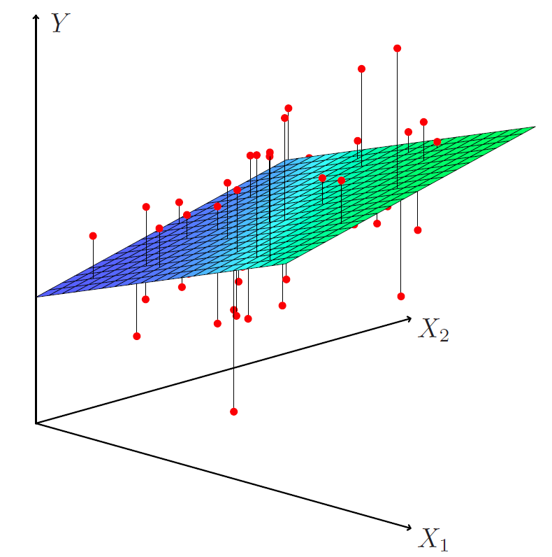

```python
# for 3D plot
from mpl_toolkits.mplot3d import Axes3D
```

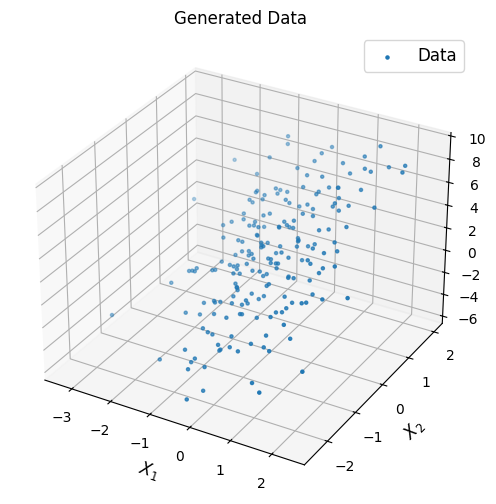

```python
# y = theta0 + theta1*x1 + theta2*x2 + noise

n = 200
x1 = np.random.randn(n, 1)
x2 = np.random.randn(n, 1)
noise = 0.5*np.random.randn(n, 1);

y = 2 + 1*x1 + 3*x2 + noise

fig = plt.figure(figsize = (8, 6))
ax = fig.add_subplot(1, 1, 1, projection = '3d')
ax.set_title('Generated Data', fontsize = 12)
ax.set_xlabel('$X_1$', fontsize = 12)
ax.set_ylabel('$X_2$', fontsize = 12)
ax.set_zlabel('Y', fontsize = 12)
ax.scatter(x1, x2, y, marker = '.', label = 'Data')
#ax.view_init(30,30)
plt.legend(fontsize = 12)
plt.show()
```

We can represent the multivariate linear regression problem compactly in matrix form:

$$\Phi = \begin{bmatrix}1 & x_{1}^{(1)} & x_{2}^{(1)}\\1 & x_{1}^{(2)} & x_{2}^{(2)}\\ \vdots \\1 & x_{1}^{(m)} & x_{2}^{(m)} \end{bmatrix} \quad \implies \quad \hat{y} = \begin{bmatrix}\hat{y}^{(1)} \\\hat{y}^{(2)} \\\vdots \\\hat{y}^{(m)}\end{bmatrix}=\Phi\theta$$

The corresponding least squares solution for the optimal parameter vector $\theta$ is:

$$ \theta^{*} = (\Phi^T \Phi)^{-1} \Phi^T y$$

In matrix form, the least-squares solution remains identical in its formulation. The only difference is that when extending to multivariate regression, more columns are included in the feature matrix $\Phi$, representing additional independent variables.

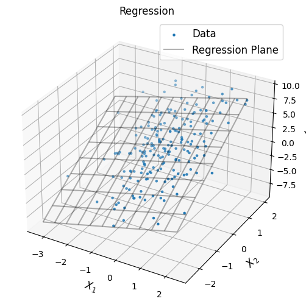

```python
A = np.hstack([np.ones((n, 1)), x1, x2])
A = np.asmatrix(A)
theta = (A.T*A).I*A.T*y

X1, X2 = np.meshgrid(np.arange(np.min(x1), np.max(x1), 0.5),
                     np.arange(np.min(x2), np.max(x2), 0.5))
YP = theta[0,0] + theta[1,0]*X1 + theta[2,0]*X2

fig = plt.figure(figsize = (8, 6))
ax = fig.add_subplot(1, 1, 1, projection = '3d')
ax.set_title('Regression', fontsize = 12)
ax.set_xlabel('$X_1$', fontsize = 12)
ax.set_ylabel('$X_2$', fontsize = 12)
ax.set_zlabel('Y', fontsize = 12)
ax.scatter(x1, x2, y, marker = '.', label = 'Data')
ax.plot_wireframe(X1, X2, YP, color = 'k', alpha = 0.3, label = 'Regression Plane')
#ax.view_init(30,30)
plt.legend(fontsize = 12)
plt.show()
```

## 2.2. Feature (or Input) Importance in Multivariate Linear Regression

In multivariate linear regression, multiple features (inputs) contribute to predicting the target variable. However, not all features are equally important.

Understanding feature importance is essential for:

- Model interpretability
- Feature selection
- Improving generalization and performance

The prediction model is expressed as:

$$ \hat{y} = \theta_0 + \theta_{1}x_1 + \theta_{2}x_2 + \cdots $$

The importance of a feature is directly related to the magnitude of its coefficient $\theta_i$.

- A larger $\lvert \theta_i \rvert$ suggests a stronger influence on the predicted outcome.
- A smaller $\lvert \theta_i \rvert$ implies the feature has minimal effect and may be considered for removal.

Potential issue: Features may be on different scales, which can distort the comparison of coefficients. Feature scaling or standardization is important before interpreting weights.

## 2.3. Feature Selection in Multivariate Linear Regression

In multivariate linear regression, some features may have little impact on the target variable. If a feature's coefficient is relatively small compared to others, it contributes minimally to the prediction and can be eliminated to simplify the model. Simplifying the model leads to better generalization and computational efficiency.

**Example**

Before feature selection:

$$ \hat y = 3.2x_1 + 0.01x_2 - 2.5x_3 + 0.0001x_4 $$

Here, $x_2$ and $x_4$ have negligible impact on the output.

After feature selection:

$$ \hat y = 3.2x_1 - 2.5x_3 $$

By eliminating $x_2$ and $x_4$, the model becomes simpler, easier to interpret, and computationally efficient.

(1) Real-World Insight:

If the original model relied on four sensors to measure the input features, feature selection suggests that only two sensors are truly necessary - reducing cost, complexity, and maintenance without sacrificing performance.

(2) Control Perspective:

In a control system, where the predicted output $\hat y$ needs to match a desired target:

- The regression model can be used proactively to adjust inputs and steer the system.
- If $\hat y$ is too low, you can:
  - Increase $x_1$ (since it has a positive weight)
  - Decrease $x_3$ (since it has a negative weight)

This makes regression models not just predictive but also actionable, guiding decisions and interventions in real-time systems.

# 3. Nonlinear Regression

Linear regression is a foundational technique in statistical modeling that assumes a straight-line (linear) relationship between the independent variables and the dependent variable. It finds the line that best fits the data points by minimizing the sum of squared errors. This approach works well if the underlying relationship in the data is approximately linear. However, when the data exhibit a nonlinear pattern, a straight line may not adequately capture the relationship, leading to large errors or systematic patterns in the residuals.

When a linear model is insufficient, one should consider using nonlinear regression techniques that can accommodate curvature or other complex nonlinear behaviors in the data. In such cases, it is natural to transition from a linear regression approach to a nonlinear regression model in order to better fit the data.

This section explores how to construct a regression model capable of approximating non-linearly distributed data.

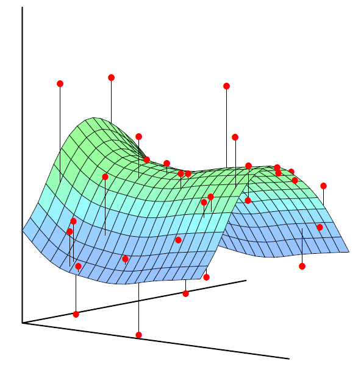

## 3.1. Nonlinear Regression with Polynomial Features

One of the simplest approaches to nonlinear regression is polynomial regression, which extends linear regression by incorporating polynomial terms to capture curvature in the data.

Consider a dataset consisting of paired data points $(x_i, y_i)$, where each $x_i$ is an independent variable and $y_i$ is the corresponding dependent variable. Instead of modeling $y$ as a simple linear function of $x$, polynomial regression extends the feature set by including higher-order terms:

$$ \begin{align*} y &= \theta_0 + \theta_1 x + \theta_2 x^2 + \text{noise} \end{align*} $$

$$\phi(x_{i}) = \begin{bmatrix}1\\x_{i}\\x_{i}^2 \end{bmatrix}$$

Here, quad is used as an example and $\Phi$ is constructed using powers of $x$, forming an augmented feature space:

$$\Phi = \begin{bmatrix}1 & x_{1} & x_{1}^2 \\ 1 & x_{2} & x_{2}^2 \\ \vdots \\ 1 & x_{m} & x_{m}^2\end{bmatrix} \quad \implies \quad \hat{y} = \begin{bmatrix}\hat{y}_1 \\\hat{y}_2 \\\vdots \\\hat{y}_m\end{bmatrix}=\Phi\theta$$

where each row represents an observation, and each column corresponds to a different polynomial term.

Although the equation appears nonlinear in terms of $x$, it remains linear in terms of the unknown parameters $\theta$. The model is still solvable using linear regression techniques, such as the least-squares method:

$$\implies \theta^{*} = (\Phi^T \Phi)^{-1} \Phi^T y$$

[figure not shown]

```python
# y = theta0 + theta1*x + theta2*x^2 + noise

n = 100
x = -5 + 15*np.random.rand(n, 1)
noise = 10*np.random.randn(n, 1)

y = 10 + 1*x + 2*x**2 + noise

plt.figure(figsize = (6, 4))
plt.xlabel('X')
plt.ylabel('Y')
plt.plot(x, y, 'o', markersize = 4, alpha = 0.3)
plt.grid(alpha = 0.3)
plt.show()
```

```python
A = np.hstack([x**0, x, x**2])
A = np.asmatrix(A)

theta = (A.T*A).I*A.T*y
print('theta:\n', theta)
```

```
theta:
 [[11.47683907]
 [ 1.07754213]
 [ 1.93265672]]
```

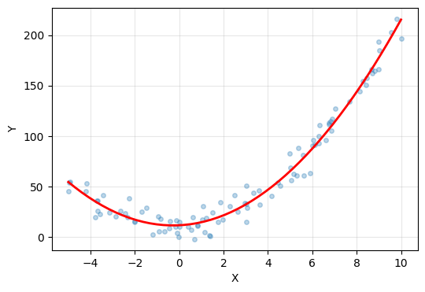

```python
xp = np.linspace(np.min(x), np.max(x))
yp = theta[0,0] + theta[1,0]*xp + theta[2,0]*xp**2

plt.figure(figsize = (6, 4))
plt.plot(x, y, 'o', markersize = 4, alpha = 0.3)
plt.plot(xp, yp, 'r', linewidth = 2)

plt.xlabel('X')
plt.ylabel('Y')
plt.grid(alpha = 0.3)
plt.show()
```

By understanding this example, we can effectively model nonlinear patterns using polynomial regression while leveraging the simplicity of linear regression methods.

## 3.2. Linear Basis Function Models

In the above section, we introduced polynomial regression. However, here, we interpret the same method from a slightly different perspective. We have learned that matrix-vector multiplication can be thought of as a linear combination of the columns of the matrix, with coefficients given by the vector. If $\Phi$ consists of columns representing basis functions, then $\Phi \theta$ represents one of the functions that is spanned by these basis functions.

This approach is referred to as linear basis function models. With this perspective, polynomial regression can be viewed as a special case of linear basis function models, where the basis functions are polynomials.

Consider linear combinations of fixed nonlinear functions of the input variables, of the form

$$ \begin{bmatrix} 1 & x_{1} & x_1^2\\1 & x_{2} & x_2^2\\\vdots & \vdots\\1 & x_{m} & x_m^2 \end{bmatrix} \begin{bmatrix}\theta_0\\\theta_1 \\ \theta_2 \end{bmatrix} \quad \implies \quad \begin{bmatrix} \mid & \mid & \mid \\ b_0(x) & b_1(x) & b_2(x)\\ \mid & \mid & \mid \end{bmatrix} \begin{bmatrix}\theta_0\\\theta_1 \\ \theta_2 \end{bmatrix} $$

$$ \hat{y}=\sum_{i=0}^d{\theta_i b_i(x)} = \Phi \theta$$

**1) Polynomial functions**

$$b_i(x) = x^i, \quad i = 0,\cdots,d$$

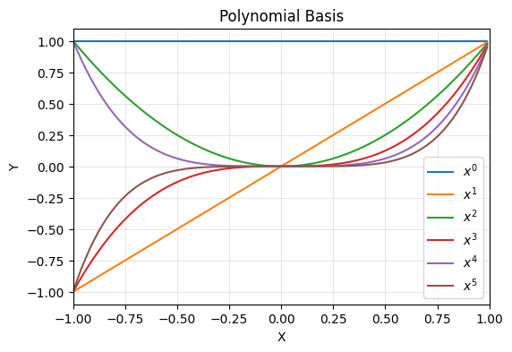

```python
xp = np.arange(-1, 1, 0.01).reshape(-1, 1)
polybasis = np.hstack([xp**i for i in range(6)])

plt.figure(figsize = (6, 4))

for i in range(6):
    plt.plot(xp, polybasis[:,i], label = '$x^{}$'.format(i))

plt.title('Polynomial Basis')
plt.xlabel('X')
plt.ylabel('Y')
plt.axis([-1, 1, -1.1, 1.1])
plt.grid(alpha = 0.3)
plt.legend()
plt.show()
```

For instance, if the coefficients are $[-1, 1, 1, -1, 1, -1]^T$ with the polynomial basis, the nonlinear function would be:

$$\hat y = -1 + 1 \cdot x + 1 \cdot x^2 - 1 \cdot x^3 + 1 \cdot x^4 -1 \cdot x^5$$

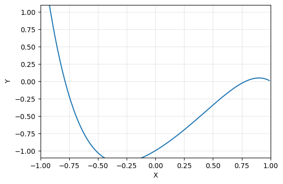

```python
theta = np.array([-1, 1, 1, -1, 1, -1])
yhat = polybasis.dot(theta)

plt.figure(figsize = (6, 4))

plt.plot(xp, yhat)
plt.xlabel('X')
plt.ylabel('Y')
plt.axis([-1, 1, -1.1, 1.1])
plt.grid(alpha = 0.3)
plt.show()
```

The form of a nonlinear function is determined by the specific values of its coefficients. Consequently, solving a nonlinear regression problem involves identifying the set of coefficients that enable the function to most accurately approximate the given data points.

**2) RBF functions**

A Radial Basis Function (RBF) is a type of basis function whose value depends only on the distance between the input and a fixed center point.

- Gaussian RBF (most commonly used) with bandwidth $\sigma$ and $k$ RBF centers $\mu_i \in \mathbb{R}^n$

$$ b_i(x) = \exp \left( - \frac{\lVert x-\mu_i \rVert^2}{2\sigma^2}\right) $$

- Useful for capturing localized patterns

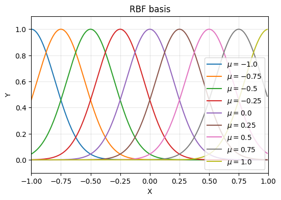

```python
d = 9

u = np.linspace(-1, 1, d)
sigma = 0.2

rbfbasis = np.hstack([np.exp(-(xp-u[i])**2/(2*sigma**2)) for i in range(d)])

plt.figure(figsize = (6, 4))

for i in range(d):
    plt.plot(xp, rbfbasis[:,i], label='$\mu = {}$'.format(u[i]))

plt.title('RBF basis')
plt.xlabel('X')
plt.ylabel('Y')
plt.axis([-1, 1, -0.1, 1.1])
plt.legend(loc = 'lower right')
plt.grid(alpha = 0.3)
plt.show()
```

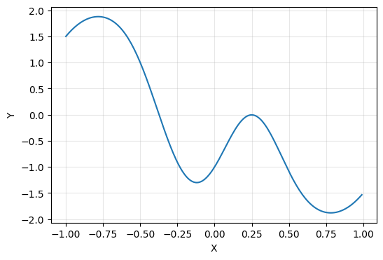

```python
theta = np.array([1, 1, 1, -1, -1, 1, -1, -1, -1])
yhat = rbfbasis.dot(theta)

plt.figure(figsize = (6, 4))

plt.plot(xp, yhat)
plt.xlabel('X')
plt.ylabel('Y')
# plt.axis([-1, 1, -1.1, 1.1])
plt.grid(alpha = 0.3)
plt.show()
```

**Nonlinear regression with linear basis function models**

We are now ready to perform nonlinear regression on the given data points.

(1) Polynomial functions

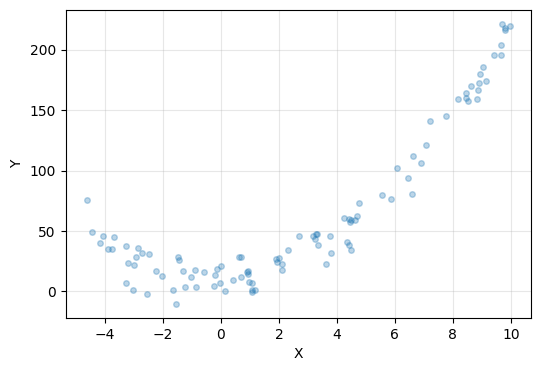

```python
n = 100
x = -5 + 15*np.random.rand(n, 1)
noise = 10*np.random.randn(n, 1)

y = 10 + 1*x + 2*x**2 + noise

plt.figure(figsize = (6, 4))
plt.xlabel('X')
plt.ylabel('Y')
plt.plot(x, y, 'o', markersize = 4, alpha = 0.3)
plt.grid(alpha = 0.3)
plt.show()
```

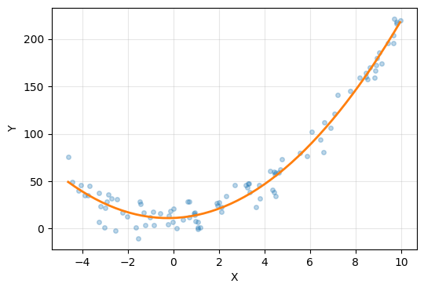

```python
xp = np.linspace(np.min(x), np.max(x)).reshape(-1, 1)

d = 3

A = np.hstack([x**i for i in range(d)])
polybasis = np.hstack([xp**i for i in range(d)])

A = np.asmatrix(A)
polybasis = np.asmatrix(polybasis)

theta = (A.T*A).I*A.T*y
yp = polybasis*theta

plt.figure(figsize = (6, 4))
plt.plot(x, y, 'o', markersize = 4, alpha = 0.3)
plt.plot(xp[:,0], yp[:,0], linewidth = 2)
plt.xlabel('X')
plt.ylabel('Y')
plt.grid(alpha = 0.3)
plt.show()
```

(2) RBF functions

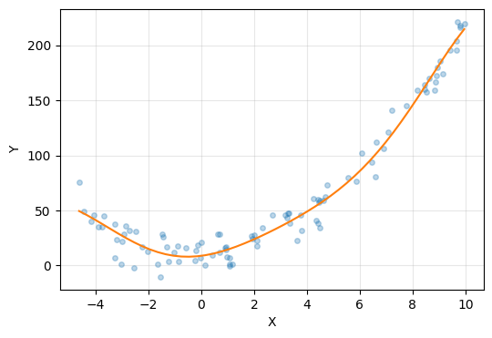

```python
xp = np.linspace(np.min(x), np.max(x)).reshape(-1, 1)

d = 5
u = np.linspace(-6, 12, d)
sigma = 3

A = np.hstack([np.exp(-(x-u[i])**2/(2*sigma**2)) for i in range(d)])
rbfbasis = np.hstack([np.exp(-(xp-u[i])**2/(2*sigma**2)) for i in range(d)])

A = np.asmatrix(A)
rbfbasis = np.asmatrix(rbfbasis)

theta = (A.T*A).I*A.T*y
yp = rbfbasis*theta

plt.figure(figsize = (6, 4))
plt.plot(x, y, 'o', markersize = 4, alpha = 0.3)
plt.plot(xp, yp)
plt.xlabel('X')
plt.ylabel('Y')
plt.grid(alpha = 0.3)
plt.show()
```

Nonlinear regression utilizing polynomial features and linear basis function models employing polynomial basis functions are fundamentally equivalent in their mathematical structure. Both approaches aim to model complex, nonlinear relationships by transforming the original input variables into a higher-dimensional space where linear regression techniques can be applied. In the case of polynomial regression, this transformation involves augmenting the input data with polynomial terms (e.g., $ x, x^2, x^3, \cdots $), effectively enabling the modeling of nonlinear patterns within the data. Similarly, linear basis function models utilize polynomial basis functions to achieve a comparable transformation, facilitating the capture of nonlinear relationships through a linear modeling framework.

Despite this equivalence, the two methodologies offer distinct perspectives in terms of implementation and interpretation. Polynomial regression is often viewed as an extension of linear regression, where additional polynomial terms are included to account for curvature in the data. This approach is straightforward and leverages the simplicity of linear models, making it accessible and interpretable. On the other hand, linear basis function models provide a more generalized framework, allowing for the incorporation of various types of basis functions beyond polynomials, such as splines or radial basis functions. This flexibility enables practitioners to tailor the model to the specific characteristics of the data, potentially enhancing predictive performance and interpretability.

# 4. Overfitting

In machine learning, one of the most common challenges is **overfitting**. Overfitting occurs when a model learns not only the important patterns in the training data but also the noise and random fluctuations. Instead of performing well on new, unseen data, the model becomes highly tuned to the training data, resulting in poor generalization.

This is similar to a student who memorizes answers to specific questions rather than understanding the concepts, leading to poor performance when asked different questions. In the same way, an overfitted model may perform very well on the training set but fail to make accurate predictions on test data.

Understanding and addressing overfitting is essential for building models that generalize effectively. We introduce the concept of overfitting, its causes, and its impact on model performance. We will also cover practical methods to prevent overfitting, such as regularization.

With clear examples and explanations, this section aims to provide an understanding of overfitting and how to handle it. By the end of this section, you will be equipped with the knowledge to create models that strike the right balance between fitting the data and making reliable predictions on new data.

## 4.1. Nonlinear Regressoin with 10 Data Points

We will consider a simple case where we have ten data points and build a non-linear regression model using polynomial functions of varying degrees. By visualizing the fitted models, we will observe how the degree of the polynomial affects the fit and identify cases of underfitting, appropriate fitting, and overfitting.

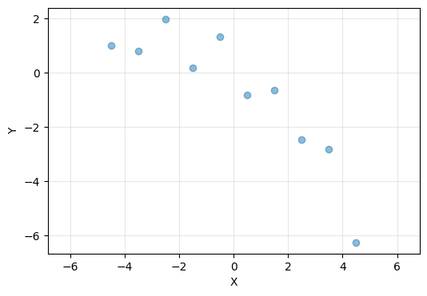

```python
import numpy as np
import matplotlib.pyplot as plt
%matplotlib inline

# 10 data points
n = 10
x = np.linspace(-4.5, 4.5, 10).reshape(-1, 1)
y = np.array([0.9819, 0.7973, 1.9737, 0.1838, 1.3180, -0.8361, -0.6591, -2.4701, -2.8122, -6.2512]).reshape(-1, 1)

plt.figure(figsize = (6, 4))
plt.plot(x, y, 'o', alpha = 0.5)
plt.xlabel('X')
plt.ylabel('Y')
plt.grid(alpha = 0.3)
plt.axis('equal')
plt.show()
```

**Degree 1 (Linear Regression):**

- The model underfits the data
- It fails to capture the non-linear pattern and results in a straight-line fit.

```python
A = np.hstack([x**0, x])
A = np.asmatrix(A)

theta = (A.T*A).I*A.T*y
print(theta)
```

[output not shown]

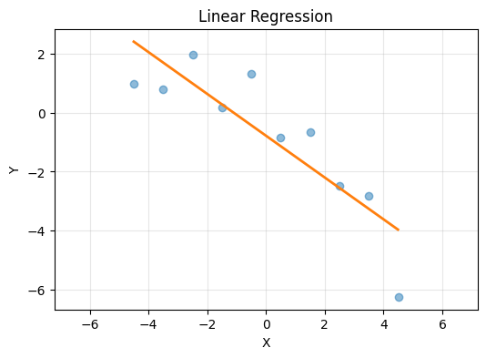

```python
# to plot
xp = np.arange(-4.5, 4.5, 0.01).reshape(-1, 1)
yp = theta[0,0] + theta[1,0]*xp

plt.figure(figsize = (6, 4))
plt.plot(x, y, 'o', alpha = 0.5)
plt.plot(xp[:,0], yp[:,0], linewidth = 2)
plt.title('Linear Regression')
plt.xlabel('X')
plt.ylabel('Y')
plt.grid(alpha = 0.3)
plt.axis('equal')
plt.show()
```

**Degree 3 (Cubic Polynomial):**

- The model fits the data well
- It captures the underlying trend without being too flexible or too rigid.

```python
A = np.hstack([x**0, x, x**2, x**3])
A = np.asmatrix(A)

theta = (A.T*A).I*A.T*y
print(theta)
```

```
[[ 0.33669062]
 [-0.58052442]
 [-0.13504129]
 [-0.00888599]]
```

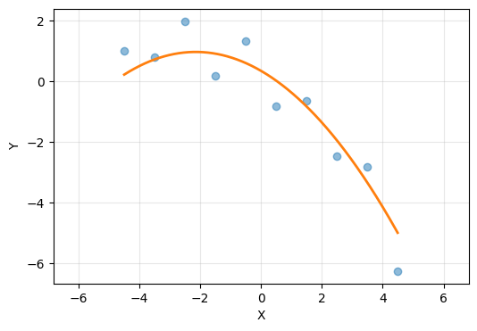

```python
# to plot
xp = np.arange(-4.5, 4.5, 0.01).reshape(-1, 1)
yp = theta[0,0] + theta[1,0]*xp + theta[2,0]*xp**2

plt.figure(figsize = (6, 4))
plt.plot(x, y, 'o', alpha = 0.5)
plt.plot(xp[:,0], yp[:,0], linewidth = 2)
plt.xlabel('X')
plt.ylabel('Y')
plt.grid(alpha = 0.3)
plt.axis('equal')
plt.show()
```

**Degree 9 (High-Degree Polynomial):**

- The model overfits the data
- It closely follows every data point, including noise, resulting in a wavy curve that fails to generalize well to unseen data.

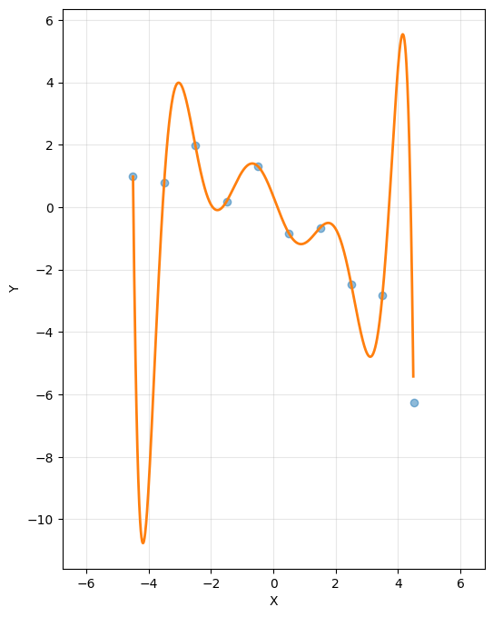

```python
A = np.hstack([x**i for i in range(10)])
A = np.asmatrix(A)

theta = (A.T*A).I*A.T*y

# to plot
xp = np.arange(-4.5, 4.5, 0.01).reshape(-1, 1)

polybasis = np.hstack([xp**i for i in range(10)])
polybasis = np.asmatrix(polybasis)

yp = polybasis*theta

plt.figure(figsize = (6, 8))
plt.plot(x, y, 'o', alpha = 0.5)
plt.plot(xp[:,0], yp[:,0], linewidth = 2)
plt.xlabel('X')
plt.ylabel('Y')
plt.grid(alpha = 0.3)
plt.axis('equal')
plt.show()
```